# Logistic Regression Classification Model

Avi Dhaliwal

# Introduction

In this project, I will build a logistic regression classification model to analyze a dataset related to loans. The objective is to classify loan statuses based on various predictors. Logistic regression is a widely used statistical method for binary classification problems, making it suitable for this task.

In addition to building the model, I will also focus on evaluating its performance using appropriate metrics and techniques. This will involve data splitting, cross-validation, and assessing the model’s accuracy, precision, recall, and other relevant measures. By conducting a thorough analysis and model evaluation, we can ensure the reliability and effectiveness of our logistic regression model in predicting loan statuses.

Throughout this project, we will follow a structured approach, starting with exploratory data analysis to understand the dataset, followed by data preprocessing to prepare the data for modeling.

We will then fit the logistic regression model, tune its hyperparameters, and evaluate its performance using various metrics.

Finally, we will discuss the model’s practical considerations, such as deployment and maintenance, and explore potential future improvements and extensions.

By the end of this project, we aim to have a robust and well-performing logistic regression model that can accurately classify loan statuses based on the given predictors. This model can serve as a valuable tool for financial institutions in making data-driven decisions and managing credit risk effectively.

# Exploratory Data Analysis

Exploratory Data Analysis (EDA) is a crucial step in any data science project. It involves understanding the dataset, its structure, and the relationships between variables. In this section, we will perform various analyses to gain insights into our loan dataset.

## Data Loading and Overview

Let’s start by loading the necessary libraries and the dataset.

```r
# Load necessary libraries
library(ggplot2)
library(dplyr)
library(readr)
library(skimr)
library(corrplot)
# Load the data
loan_data <- read_csv("loan_data.csv")
# Display the structure of the data
str(loan_data)
```

```
## spc_tbl_ [9,578 × 14] (S3: spec_tbl_df/tbl_df/tbl/data.frame)
##  $ credit.policy    : num [1:9578] 1 1 1 1 1 1 1 1 1 1 ...
##  $ purpose          : chr [1:9578] "debt_consolidation" "credit_card" "debt_consolidation" "debt_consolidation" ...
##  $ int.rate         : num [1:9578] 0.119 0.107 0.136 0.101 0.143 ...
##  $ installment      : num [1:9578] 829 228 367 162 103 ...
##  $ log.annual.inc   : num [1:9578] 11.4 11.1 10.4 11.4 11.3 ...
##  $ dti              : num [1:9578] 19.5 14.3 11.6 8.1 15 ...
##  $ fico             : num [1:9578] 737 707 682 712 667 727 667 722 682 707 ...
##  $ days.with.cr.line: num [1:9578] 5640 2760 4710 2700 4066 ...
##  $ revol.bal        : num [1:9578] 28854 33623 3511 33667 4740 ...
##  $ revol.util       : num [1:9578] 52.1 76.7 25.6 73.2 39.5 51 76.8 68.6 51.1 23 ...
##  $ inq.last.6mths   : num [1:9578] 0 0 1 1 0 0 0 0 1 1 ...
##  $ delinq.2yrs      : num [1:9578] 0 0 0 0 1 0 0 0 0 0 ...
##  $ pub.rec          : num [1:9578] 0 0 0 0 0 0 1 0 0 0 ...
##  $ not.fully.paid   : num [1:9578] 0 0 0 0 0 0 1 1 0 0 ...
##  - attr(*, "spec")=
##   .. cols(
##   ..   credit.policy = col_double(),
##   ..   purpose = col_character(),
##   ..   int.rate = col_double(),
##   ..   installment = col_double(),
##   ..   log.annual.inc = col_double(),
##   ..   dti = col_double(),
##   ..   fico = col_double(),
##   ..   days.with.cr.line = col_double(),
##   ..   revol.bal = col_double(),
##   ..   revol.util = col_double(),
##   ..   inq.last.6mths = col_double(),
##   ..   delinq.2yrs = col_double(),
##   ..   pub.rec = col_double(),
##   ..   not.fully.paid = col_double()
##   .. )
##  - attr(*, "problems")=<externalptr>
```

```r
# Display summary statistics
summary(loan_data)
```

```
##  credit.policy     purpose             int.rate       installment
##  Min.   :0.000   Length:9578        Min.   :0.0600   Min.   : 15.67
##  1st Qu.:1.000   Class :character   1st Qu.:0.1039   1st Qu.:163.77
##  Median :1.000   Mode  :character   Median :0.1221   Median :268.95
##  Mean   :0.805                      Mean   :0.1226   Mean   :319.09
##  3rd Qu.:1.000                      3rd Qu.:0.1407   3rd Qu.:432.76
##  Max.   :1.000                      Max.   :0.2164   Max.   :940.14
##  log.annual.inc        dti              fico       days.with.cr.line
##  Min.   : 7.548   Min.   : 0.000   Min.   :612.0   Min.   :  179
##  1st Qu.:10.558   1st Qu.: 7.213   1st Qu.:682.0   1st Qu.: 2820
##  Median :10.929   Median :12.665   Median :707.0   Median : 4140
##  Mean   :10.932   Mean   :12.607   Mean   :710.8   Mean   : 4561
##  3rd Qu.:11.291   3rd Qu.:17.950   3rd Qu.:737.0   3rd Qu.: 5730
##  Max.   :14.528   Max.   :29.960   Max.   :827.0   Max.   :17640
##    revol.bal         revol.util    inq.last.6mths    delinq.2yrs
##  Min.   :      0   Min.   :  0.0   Min.   : 0.000   Min.   : 0.0000
##  1st Qu.:   3187   1st Qu.: 22.6   1st Qu.: 0.000   1st Qu.: 0.0000
##  Median :   8596   Median : 46.3   Median : 1.000   Median : 0.0000
##  Mean   :  16914   Mean   : 46.8   Mean   : 1.577   Mean   : 0.1637
##  3rd Qu.:  18250   3rd Qu.: 70.9   3rd Qu.: 2.000   3rd Qu.: 0.0000
##  Max.   :1207359   Max.   :119.0   Max.   :33.000   Max.   :13.0000
##     pub.rec        not.fully.paid
##  Min.   :0.00000   Min.   :0.0000
##  1st Qu.:0.00000   1st Qu.:0.0000
##  Median :0.00000   Median :0.0000
##  Mean   :0.06212   Mean   :0.1601
##  3rd Qu.:0.00000   3rd Qu.:0.0000
##  Max.   :5.00000   Max.   :1.0000
```

In addition to the basic structure and summary statistics, we can use the skim() function from the skimr package to get a more detailed overview of the dataset. This function provides information such as the data type, missing values, and distribution statistics for each variable.

```r
# Detailed data overview
skim(loan_data)
```

Data summary

| Name | loan_data |
| --- | --- |
| Number of rows | 9578 |
| Number of columns | 14 |
| _______________________ |  |
| Column type frequency: |  |
| character | 1 |
| numeric | 13 |
| ________________________ |  |
| Group variables | None |

**Variable type: character**

| skim_variable | n_missing | complete_rate | min | max | empty | n_unique | whitespace |
| --- | --- | --- | --- | --- | --- | --- | --- |
| purpose | 0 | 1 | 9 | 18 | 0 | 7 | 0 |

**Variable type: numeric**

| skim_variable | n_missing | complete_rate | mean | sd | p0 | p25 | p50 | p75 | p100 | hist |
| --- | --- | --- | --- | --- | --- | --- | --- | --- | --- | --- |
| credit.policy | 0 | 1 | 0.80 | 0.40 | 0.00 | 1.00 | 1.00 | 1.00 | 1.00 | ▂▁▁▁▇ |
| int.rate | 0 | 1 | 0.12 | 0.03 | 0.06 | 0.10 | 0.12 | 0.14 | 0.22 | ▃▇▇▂▁ |
| installment | 0 | 1 | 319.09 | 207.07 | 15.67 | 163.77 | 268.95 | 432.76 | 940.14 | ▇▇▃▂▁ |
| log.annual.inc | 0 | 1 | 10.93 | 0.61 | 7.55 | 10.56 | 10.93 | 11.29 | 14.53 | ▁▂▇▁▁ |
| dti | 0 | 1 | 12.61 | 6.88 | 0.00 | 7.21 | 12.66 | 17.95 | 29.96 | ▆▇▇▆▁ |
| fico | 0 | 1 | 710.85 | 37.97 | 612.00 | 682.00 | 707.00 | 737.00 | 827.00 | ▁▇▆▃▁ |
| days.with.cr.line | 0 | 1 | 4560.77 | 2496.93 | 178.96 | 2820.00 | 4139.96 | 5730.00 | 17639.96 | ▇▇▂▁▁ |
| revol.bal | 0 | 1 | 16913.96 | 33756.19 | 0.00 | 3187.00 | 8596.00 | 18249.50 | 1207359.00 | ▇▁▁▁▁ |
| revol.util | 0 | 1 | 46.80 | 29.01 | 0.00 | 22.60 | 46.30 | 70.90 | 119.00 | ▇▇▇▆▁ |
| inq.last.6mths | 0 | 1 | 1.58 | 2.20 | 0.00 | 0.00 | 1.00 | 2.00 | 33.00 | ▇▁▁▁▁ |
| delinq.2yrs | 0 | 1 | 0.16 | 0.55 | 0.00 | 0.00 | 0.00 | 0.00 | 13.00 | ▇▁▁▁▁ |
| pub.rec | 0 | 1 | 0.06 | 0.26 | 0.00 | 0.00 | 0.00 | 0.00 | 5.00 | ▇▁▁▁▁ |
| not.fully.paid | 0 | 1 | 0.16 | 0.37 | 0.00 | 0.00 | 0.00 | 0.00 | 1.00 | ▇▁▁▁▂ |

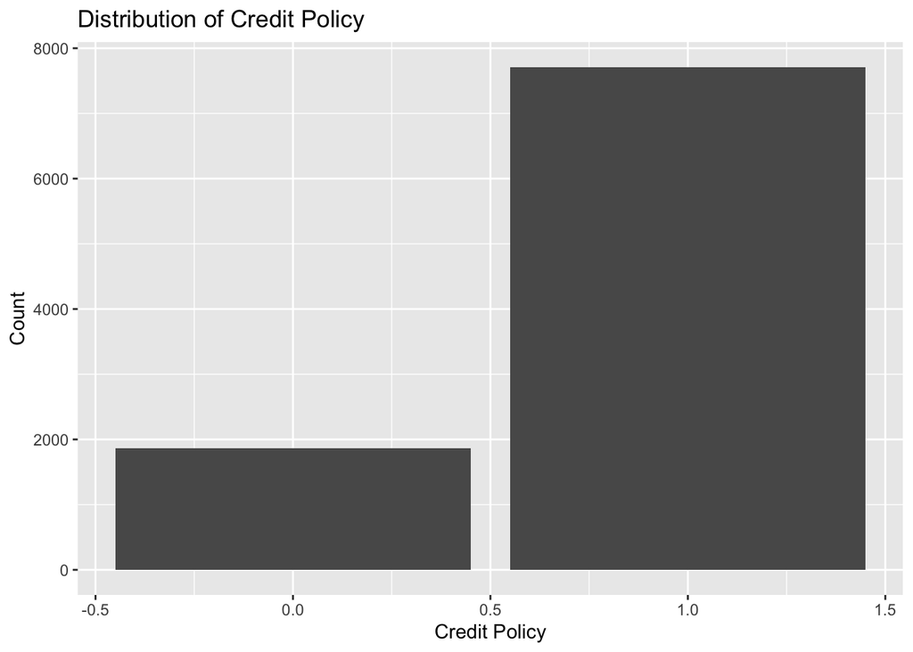

```r
# Distribution of the target variable
ggplot(loan_data, aes(x = credit.policy)) +
  geom_bar() +
  labs(title = "Distribution of Credit Policy", x = "Credit Policy", y = "Count")
```

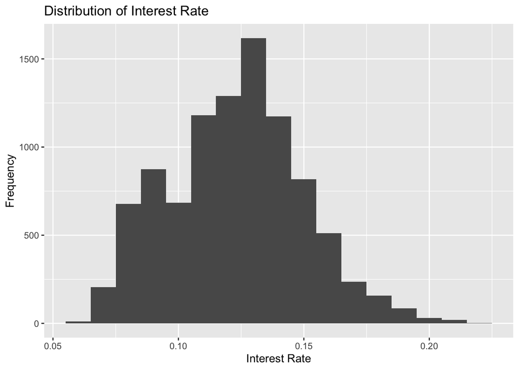

```r
# Histogram of interest rate
ggplot(loan_data, aes(x = int.rate)) +
  geom_histogram(binwidth = 0.01) +
  labs(title = "Distribution of Interest Rate", x = "Interest Rate", y = "Frequency")
```

Distribution of Interest Rate

```r
# Summary statistics for numeric variables
loan_data %>%
  select_if(is.numeric) %>%
  summary()
```

```
##  credit.policy      int.rate       installment     log.annual.inc
##  Min.   :0.000   Min.   :0.0600   Min.   : 15.67   Min.   : 7.548
##  1st Qu.:1.000   1st Qu.:0.1039   1st Qu.:163.77   1st Qu.:10.558
##  Median :1.000   Median :0.1221   Median :268.95   Median :10.929
##  Mean   :0.805   Mean   :0.1226   Mean   :319.09   Mean   :10.932
##  3rd Qu.:1.000   3rd Qu.:0.1407   3rd Qu.:432.76   3rd Qu.:11.291
##  Max.   :1.000   Max.   :0.2164   Max.   :940.14   Max.   :14.528
##       dti              fico       days.with.cr.line   revol.bal
##  Min.   : 0.000   Min.   :612.0   Min.   :  179     Min.   :      0
##  1st Qu.: 7.213   1st Qu.:682.0   1st Qu.: 2820     1st Qu.:   3187
##  Median :12.665   Median :707.0   Median : 4140     Median :   8596
##  Mean   :12.607   Mean   :710.8   Mean   : 4561     Mean   :  16914
##  3rd Qu.:17.950   3rd Qu.:737.0   3rd Qu.: 5730     3rd Qu.:  18250
##  Max.   :29.960   Max.   :827.0   Max.   :17640     Max.   :1207359
##    revol.util    inq.last.6mths    delinq.2yrs         pub.rec
##  Min.   :  0.0   Min.   : 0.000   Min.   : 0.0000   Min.   :0.00000
##  1st Qu.: 22.6   1st Qu.: 0.000   1st Qu.: 0.0000   1st Qu.:0.00000
##  Median : 46.3   Median : 1.000   Median : 0.0000   Median :0.00000
##  Mean   : 46.8   Mean   : 1.577   Mean   : 0.1637   Mean   :0.06212
##  3rd Qu.: 70.9   3rd Qu.: 2.000   3rd Qu.: 0.0000   3rd Qu.:0.00000
##  Max.   :119.0   Max.   :33.000   Max.   :13.0000   Max.   :5.00000
##  not.fully.paid
##  Min.   :0.0000
##  1st Qu.:0.0000
##  Median :0.0000
##  Mean   :0.1601
##  3rd Qu.:0.0000
##  Max.   :1.0000
```

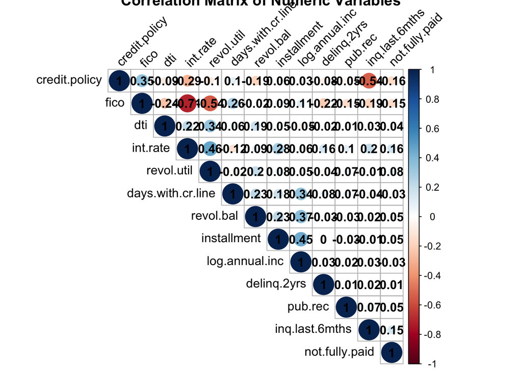

```r
# Ensure correct subsetting for numeric columns
numeric_cols <- sapply(loan_data, is.numeric)
numeric_data <- loan_data[, numeric_cols]

# Calculate correlation matrix
cor_matrix <- cor(numeric_data, use = "complete.obs")

# Plot correlation matrix
corrplot(cor_matrix, method = "circle", type = "upper", order = "hclust",
         addCoef.col = "black", tl.col = "black", tl.srt = 45,
         title = "Correlation Matrix of Numeric Variables")
```

Correlation Matrix of Numeric Variables

Description: This correlation plot is a heatmap that visually represents the pairwise correlation coefficients between the numeric variables in the dataset. The plot uses both color intensity and numeric values to indicate the strength and direction of the correlations.

Interpretation:

The plot helps to quickly identify strong relationships between variables.